# Eflows Species Clustering in CA Regions

## Map of Region Breakouts

The region was broken out primarily into * Coast (North Coast->Santa Barbara) * Central Valley (anything draining out through the Central Valley - excludes Honey/Eagle Lakes) * Great Basin (anything in hydrologic region 16 in the northern part of the state, contiguous) * Desert (southern coast, including LA, and anything in the desert regions. Includes eastern sierra that is part of region 18, souther reaches of region 15 in the state, portion of Colorado River, and a small piece of region 16)

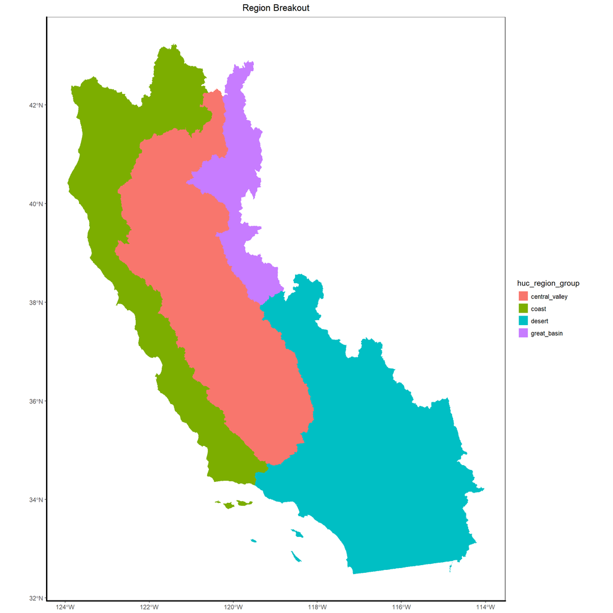

```r
writeLines("td, th { padding : 6px } th { background-color : #fff ; color : #000; border : 1px solid #333; } td { color : #000 ; border : 1px solid #333 }", con = "mystyle.css")  # add the CSS for the data tables

flow_sense_data <- file.path("C:/Users/dsx/Code/eflow-species/data/clustering/groupings/flowsensitive_current.gpkg")
region_data <- sf::st_as_sf(rgdal::readOGR(flow_sense_data, "flowsensitive_current", stringsAsFactors=FALSE))
ggplot() +
  geom_sf(region_data, lwd = 5, mapping=aes(fill=huc_region_group), color=NA)+
  ggtitle("Region Breakout") +
  theme_bw()+
  theme(panel.grid.major = element_line(colour = 'transparent'))+
  theme(strip.background = element_blank(), # facet theme control
        strip.placement = "outside",
        axis.line.x = element_line(color="black", size = 1),
        axis.line.y = element_line(color="black", size = 1),
        plot.title = element_text(hjust = 0.5))
```

## Central Valley

```r
region_name = "centralvalley"
species_info <- species_maps(region_name, "Central Valley")
```

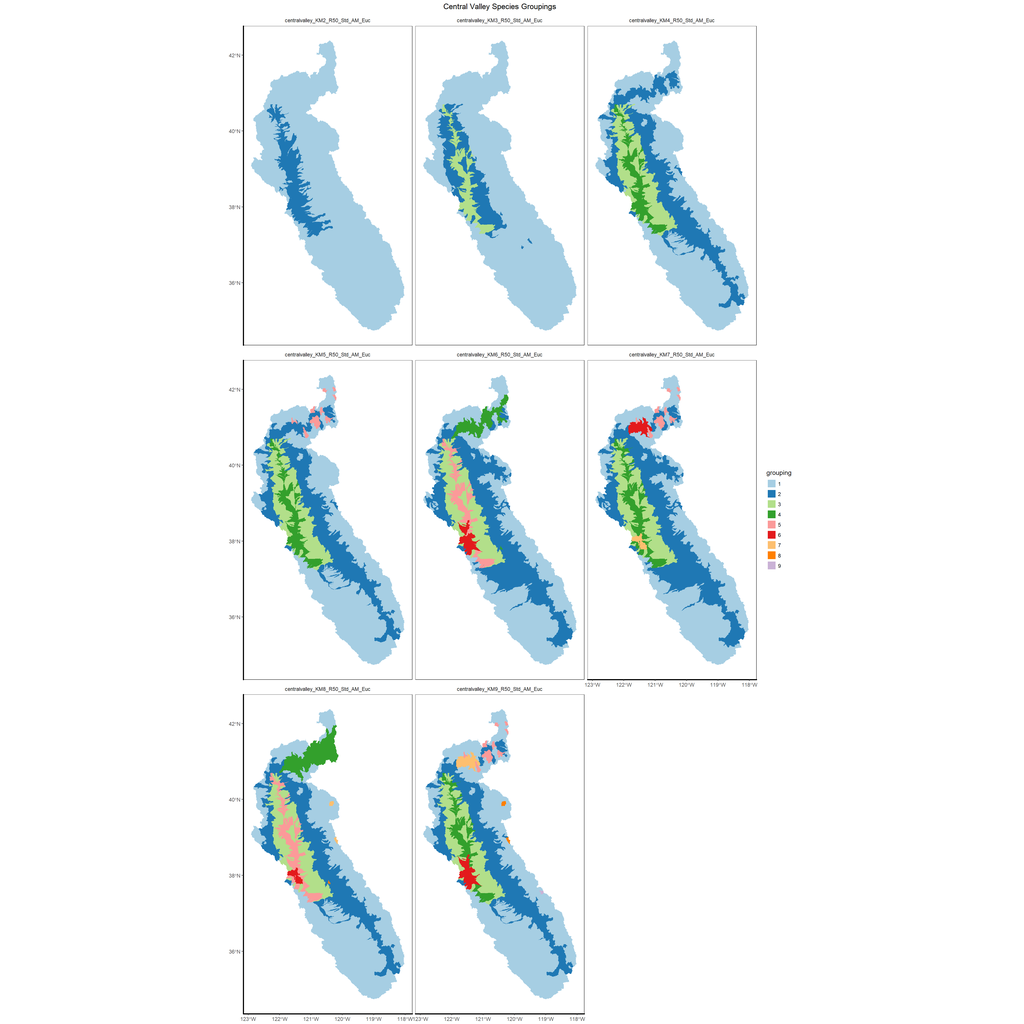

```r
species_info$region_map  # print the map
```

```r
species_lists <- species_lists_by_group_dfs(species_info$species_data, region_name)  # species_info$species_data is the data frame for the region
for(df in species_lists){
  show(knitr::kable(df, format="html"))
}
```

| group_1 | group_2 |
| --- | --- |
| Pacific_lamprey | Pacific_lamprey |
| River_lamprey | River_lamprey |
| Kern_brook_lamprey | Kern_brook_lamprey |
| Western_brook_lamprey | Western_brook_lamprey |
| Southern_green_sturgeon | Southern_green_sturgeon |
| Owens_tui_chub | White_sturgeon |
| Sacramento_hitch | Sacramento_hitch |
| Central_California_roach | Central_California_roach |
| Red_Hills_roach | Sacramento_splittail |
| Northern__Pit__roach | Hardhead |
| Sacramento_splittail | Sacramento_pikeminnow |
| Hardhead | Sacramento_speckled_dace |
| Sacramento_pikeminnow | Sacramento_sucker |
| Sacramento_speckled_dace | Longfin_smelt |
| Lahontan_mountain_sucker | Delta_smelt |
| Sacramento_sucker | Central_Valley_winter_Chinook_salmon |
| Modoc_sucker | Central_Valley_spring_Chinook_salmon |
| Delta_smelt | Central_Valley_late_fall_Chinook_salmon |
| Mountain_whitefish | Central_Valley_fall_Chinook_salmon |
| Central_Valley_spring_Chinook_salmon | Riffle_sculpin |
| Central_Valley_late_fall_Chinook_salmon | Inland_threespine_stickleback |
| Central_Valley_fall_Chinook_salmon | Sacramento_perch |
| Kern_River_rainbow_trout | Sacramento_tule_perch |
| Lahontan_cutthroat_trout | NA |
| Bigeye_marbled_sculpin | NA |
| Riffle_sculpin | NA |
| Pit_sculpin | NA |
| Inland_threespine_stickleback | NA |
| Sacramento_perch | NA |
| Sacramento_tule_perch | NA |

| group_1 | group_2 | group_3 |
| --- | --- | --- |
| Pacific_lamprey | Pacific_lamprey | Pacific_lamprey |
| Kern_brook_lamprey | River_lamprey | River_lamprey |
| Western_brook_lamprey | Kern_brook_lamprey | Western_brook_lamprey |
| Southern_green_sturgeon | Western_brook_lamprey | Southern_green_sturgeon |
| White_sturgeon | Southern_green_sturgeon | White_sturgeon |
| Owens_tui_chub | White_sturgeon | Sacramento_hitch |
| Sacramento_hitch | Sacramento_hitch | Central_California_roach |
| Central_California_roach | Central_California_roach | Sacramento_splittail |
| Northern__Pit__roach | Red_Hills_roach | Hardhead |
| Sacramento_splittail | Sacramento_splittail | Sacramento_pikeminnow |
| Hardhead | Hardhead | Sacramento_speckled_dace |
| Sacramento_pikeminnow | Sacramento_pikeminnow | Sacramento_sucker |
| Sacramento_speckled_dace | Sacramento_speckled_dace | Longfin_smelt |
| Lahontan_mountain_sucker | Sacramento_sucker | Delta_smelt |
| Sacramento_sucker | Delta_smelt | Central_Valley_winter_Chinook_salmon |
| Modoc_sucker | Central_Valley_winter_Chinook_salmon | Central_Valley_spring_Chinook_salmon |
| Mountain_whitefish | Central_Valley_spring_Chinook_salmon | Central_Valley_late_fall_Chinook_salmon |
| Central_Valley_spring_Chinook_salmon | Central_Valley_late_fall_Chinook_salmon | Central_Valley_fall_Chinook_salmon |
| Central_Valley_late_fall_Chinook_salmon | Central_Valley_fall_Chinook_salmon | Riffle_sculpin |
| Central_Valley_fall_Chinook_salmon | Riffle_sculpin | Inland_threespine_stickleback |
| Kern_River_rainbow_trout | Inland_threespine_stickleback | Sacramento_perch |
| Lahontan_cutthroat_trout | Sacramento_tule_perch | Sacramento_tule_perch |
| Bigeye_marbled_sculpin | NA | NA |
| Riffle_sculpin | NA | NA |
| Pit_sculpin | NA | NA |
| Inland_threespine_stickleback | NA | NA |
| Sacramento_perch | NA | NA |
| Sacramento_tule_perch | NA | NA |

| group_1 | group_2 | group_3 | group_4 |
| --- | --- | --- | --- |
| Pacific_lamprey | Pacific_lamprey | Pacific_lamprey | Pacific_lamprey |
| Kern_brook_lamprey | Kern_brook_lamprey | River_lamprey | River_lamprey |
| Western_brook_lamprey | Western_brook_lamprey | Kern_brook_lamprey | Western_brook_lamprey |
| Southern_green_sturgeon | Sacramento_hitch | Western_brook_lamprey | Southern_green_sturgeon |
| White_sturgeon | Central_California_roach | Southern_green_sturgeon | White_sturgeon |
| Owens_tui_chub | Red_Hills_roach | White_sturgeon | Sacramento_hitch |
| Sacramento_hitch | Northern__Pit__roach | Sacramento_hitch | Central_California_roach |
| Central_California_roach | Hardhead | Central_California_roach | Sacramento_splittail |
| Northern__Pit__roach | Sacramento_pikeminnow | Sacramento_splittail | Hardhead |
| Sacramento_splittail | Sacramento_speckled_dace | Hardhead | Sacramento_pikeminnow |
| Hardhead | Lahontan_mountain_sucker | Sacramento_pikeminnow | Sacramento_speckled_dace |
| Sacramento_pikeminnow | Sacramento_sucker | Sacramento_speckled_dace | Sacramento_sucker |
| Sacramento_speckled_dace | Modoc_sucker | Sacramento_sucker | Longfin_smelt |
| Lahontan_mountain_sucker | Central_Valley_spring_Chinook_salmon | Delta_smelt | Delta_smelt |
| Sacramento_sucker | Central_Valley_late_fall_Chinook_salmon | Central_Valley_winter_Chinook_salmon | Central_Valley_winter_Chinook_salmon |
| Modoc_sucker | Central_Valley_fall_Chinook_salmon | Central_Valley_spring_Chinook_salmon | Central_Valley_spring_Chinook_salmon |
| Mountain_whitefish | Bigeye_marbled_sculpin | Central_Valley_late_fall_Chinook_salmon | Central_Valley_late_fall_Chinook_salmon |
| Central_Valley_spring_Chinook_salmon | Riffle_sculpin | Central_Valley_fall_Chinook_salmon | Central_Valley_fall_Chinook_salmon |
| Central_Valley_late_fall_Chinook_salmon | Pit_sculpin | Riffle_sculpin | Riffle_sculpin |
| Central_Valley_fall_Chinook_salmon | Inland_threespine_stickleback | Inland_threespine_stickleback | Inland_threespine_stickleback |
| Kern_River_rainbow_trout | Sacramento_perch | Sacramento_tule_perch | Sacramento_perch |
| Lahontan_cutthroat_trout | Sacramento_tule_perch | NA | Sacramento_tule_perch |
| Bigeye_marbled_sculpin | NA | NA | NA |
| Riffle_sculpin | NA | NA | NA |
| Pit_sculpin | NA | NA | NA |
| Inland_threespine_stickleback | NA | NA | NA |
| Sacramento_perch | NA | NA | NA |
| Sacramento_tule_perch | NA | NA | NA |

| group_1 | group_2 | group_3 | group_4 | group_5 |
| --- | --- | --- | --- | --- |
| Pacific_lamprey | Pacific_lamprey | Pacific_lamprey | Pacific_lamprey | Northern__Pit__roach |
| Kern_brook_lamprey | Kern_brook_lamprey | River_lamprey | River_lamprey | Hardhead |
| Western_brook_lamprey | Western_brook_lamprey | Kern_brook_lamprey | Western_brook_lamprey | Sacramento_pikeminnow |
| Southern_green_sturgeon | Sacramento_hitch | Western_brook_lamprey | Southern_green_sturgeon | Sacramento_speckled_dace |
| White_sturgeon | Central_California_roach | Southern_green_sturgeon | White_sturgeon | Sacramento_sucker |
| Owens_tui_chub | Red_Hills_roach | White_sturgeon | Sacramento_hitch | Modoc_sucker |
| Sacramento_hitch | Hardhead | Sacramento_hitch | Central_California_roach | Bigeye_marbled_sculpin |
| Central_California_roach | Sacramento_pikeminnow | Central_California_roach | Sacramento_splittail | Pit_sculpin |
| Sacramento_splittail | Sacramento_speckled_dace | Sacramento_splittail | Hardhead | NA |
| Hardhead | Lahontan_mountain_sucker | Hardhead | Sacramento_pikeminnow | NA |
| Sacramento_pikeminnow | Sacramento_sucker | Sacramento_pikeminnow | Sacramento_speckled_dace | NA |
| Sacramento_speckled_dace | Central_Valley_spring_Chinook_salmon | Sacramento_speckled_dace | Sacramento_sucker | NA |
| Lahontan_mountain_sucker | Central_Valley_late_fall_Chinook_salmon | Sacramento_sucker | Longfin_smelt | NA |
| Sacramento_sucker | Central_Valley_fall_Chinook_salmon | Delta_smelt | Delta_smelt | NA |
| Mountain_whitefish | Bigeye_marbled_sculpin | Central_Valley_winter_Chinook_salmon | Central_Valley_winter_Chinook_salmon | NA |
| Central_Valley_spring_Chinook_salmon | Riffle_sculpin | Central_Valley_spring_Chinook_salmon | Central_Valley_spring_Chinook_salmon | NA |
| Central_Valley_late_fall_Chinook_salmon | Pit_sculpin | Central_Valley_late_fall_Chinook_salmon | Central_Valley_late_fall_Chinook_salmon | NA |
| Central_Valley_fall_Chinook_salmon | Inland_threespine_stickleback | Central_Valley_fall_Chinook_salmon | Central_Valley_fall_Chinook_salmon | NA |
| Kern_River_rainbow_trout | Sacramento_perch | Riffle_sculpin | Riffle_sculpin | NA |
| Lahontan_cutthroat_trout | Sacramento_tule_perch | Inland_threespine_stickleback | Inland_threespine_stickleback | NA |
| Bigeye_marbled_sculpin | NA | Sacramento_tule_perch | Sacramento_perch | NA |
| Riffle_sculpin | NA | NA | Sacramento_tule_perch | NA |
| Pit_sculpin | NA | NA | NA | NA |
| Inland_threespine_stickleback | NA | NA | NA | NA |
| Sacramento_perch | NA | NA | NA | NA |
| Sacramento_tule_perch | NA | NA | NA | NA |

| group_1 | group_2 | group_3 | group_4 | group_5 | group_6 |
| --- | --- | --- | --- | --- | --- |
| Pacific_lamprey | Pacific_lamprey | Pacific_lamprey | Sacramento_hitch | Pacific_lamprey | Pacific_lamprey |
| Kern_brook_lamprey | Kern_brook_lamprey | River_lamprey | Central_California_roach | River_lamprey | River_lamprey |
| Western_brook_lamprey | Western_brook_lamprey | Kern_brook_lamprey | Red_Hills_roach | Western_brook_lamprey | Western_brook_lamprey |
| Owens_tui_chub | Southern_green_sturgeon | Western_brook_lamprey | Northern__Pit__roach | Southern_green_sturgeon | Southern_green_sturgeon |
| Sacramento_hitch | White_sturgeon | Southern_green_sturgeon | Hardhead | White_sturgeon | White_sturgeon |
| Central_California_roach | Sacramento_hitch | White_sturgeon | Sacramento_pikeminnow | Sacramento_hitch | Sacramento_hitch |
| Northern__Pit__roach | Central_California_roach | Sacramento_hitch | Sacramento_speckled_dace | Central_California_roach | Sacramento_splittail |
| Sacramento_splittail | Sacramento_splittail | Central_California_roach | Sacramento_sucker | Sacramento_splittail | Hardhead |
| Hardhead | Hardhead | Sacramento_splittail | Modoc_sucker | Hardhead | Sacramento_pikeminnow |
| Sacramento_pikeminnow | Sacramento_pikeminnow | Hardhead | Bigeye_marbled_sculpin | Sacramento_pikeminnow | Sacramento_sucker |
| Sacramento_speckled_dace | Sacramento_speckled_dace | Sacramento_pikeminnow | Riffle_sculpin | Sacramento_speckled_dace | Longfin_smelt |
| Sacramento_sucker | Lahontan_mountain_sucker | Sacramento_speckled_dace | Pit_sculpin | Sacramento_sucker | Delta_smelt |
| Mountain_whitefish | Sacramento_sucker | Sacramento_sucker | Sacramento_tule_perch | Delta_smelt | Central_Valley_winter_Chinook_salmon |
| Central_Valley_spring_Chinook_salmon | Central_Valley_spring_Chinook_salmon | Delta_smelt | NA | Central_Valley_winter_Chinook_salmon | Central_Valley_spring_Chinook_salmon |
| Kern_River_rainbow_trout | Central_Valley_late_fall_Chinook_salmon | Central_Valley_spring_Chinook_salmon | NA | Central_Valley_spring_Chinook_salmon | Central_Valley_late_fall_Chinook_salmon |
| Lahontan_cutthroat_trout | Central_Valley_fall_Chinook_salmon | Central_Valley_late_fall_Chinook_salmon | NA | Central_Valley_late_fall_Chinook_salmon | Central_Valley_fall_Chinook_salmon |
| Riffle_sculpin | Kern_River_rainbow_trout | Central_Valley_fall_Chinook_salmon | NA | Central_Valley_fall_Chinook_salmon | Inland_threespine_stickleback |
| Pit_sculpin | Riffle_sculpin | Riffle_sculpin | NA | Riffle_sculpin | Sacramento_tule_perch |
| Inland_threespine_stickleback | Pit_sculpin | Inland_threespine_stickleback | NA | Inland_threespine_stickleback | NA |
| Sacramento_perch | Inland_threespine_stickleback | Sacramento_tule_perch | NA | Sacramento_perch | NA |
| NA | Sacramento_perch | NA | NA | Sacramento_tule_perch | NA |
| NA | Sacramento_tule_perch | NA | NA | NA | NA |

| group_1 | group_2 | group_3 | group_4 | group_5 | group_6 | group_7 |
| --- | --- | --- | --- | --- | --- | --- |
| Pacific_lamprey | Pacific_lamprey | Pacific_lamprey | Pacific_lamprey | Northern__Pit__roach | Central_California_roach | Pacific_lamprey |
| Kern_brook_lamprey | Kern_brook_lamprey | River_lamprey | River_lamprey | Hardhead | Northern__Pit__roach | River_lamprey |
| Western_brook_lamprey | Western_brook_lamprey | Kern_brook_lamprey | Western_brook_lamprey | Sacramento_pikeminnow | Hardhead | Western_brook_lamprey |
| Owens_tui_chub | Southern_green_sturgeon | Western_brook_lamprey | Southern_green_sturgeon | Sacramento_speckled_dace | Sacramento_pikeminnow | Southern_green_sturgeon |
| Sacramento_hitch | White_sturgeon | Southern_green_sturgeon | White_sturgeon | Sacramento_sucker | Sacramento_speckled_dace | White_sturgeon |
| Central_California_roach | Sacramento_hitch | White_sturgeon | Sacramento_hitch | Modoc_sucker | Sacramento_sucker | Sacramento_hitch |
| Sacramento_splittail | Central_California_roach | Sacramento_hitch | Central_California_roach | Pit_sculpin | Bigeye_marbled_sculpin | Sacramento_splittail |
| Hardhead | Red_Hills_roach | Central_California_roach | Sacramento_splittail | NA | Pit_sculpin | Hardhead |
| Sacramento_pikeminnow | Sacramento_splittail | Sacramento_splittail | Hardhead | NA | Sacramento_tule_perch | Sacramento_pikeminnow |
| Sacramento_speckled_dace | Hardhead | Hardhead | Sacramento_pikeminnow | NA | NA | Sacramento_sucker |
| Sacramento_sucker | Sacramento_pikeminnow | Sacramento_pikeminnow | Sacramento_speckled_dace | NA | NA | Longfin_smelt |
| Mountain_whitefish | Sacramento_speckled_dace | Sacramento_speckled_dace | Sacramento_sucker | NA | NA | Delta_smelt |
| Central_Valley_spring_Chinook_salmon | Lahontan_mountain_sucker | Sacramento_sucker | Delta_smelt | NA | NA | Central_Valley_winter_Chinook_salmon |
| Kern_River_rainbow_trout | Sacramento_sucker | Delta_smelt | Central_Valley_winter_Chinook_salmon | NA | NA | Central_Valley_spring_Chinook_salmon |
| Lahontan_cutthroat_trout | Central_Valley_spring_Chinook_salmon | Central_Valley_spring_Chinook_salmon | Central_Valley_spring_Chinook_salmon | NA | NA | Central_Valley_late_fall_Chinook_salmon |
| Riffle_sculpin | Central_Valley_late_fall_Chinook_salmon | Central_Valley_late_fall_Chinook_salmon | Central_Valley_late_fall_Chinook_salmon | NA | NA | Central_Valley_fall_Chinook_salmon |
| Pit_sculpin | Central_Valley_fall_Chinook_salmon | Central_Valley_fall_Chinook_salmon | Central_Valley_fall_Chinook_salmon | NA | NA | Inland_threespine_stickleback |
| Inland_threespine_stickleback | Kern_River_rainbow_trout | Riffle_sculpin | Riffle_sculpin | NA | NA | Sacramento_tule_perch |
| Sacramento_perch | Riffle_sculpin | Inland_threespine_stickleback | Inland_threespine_stickleback | NA | NA | NA |
| NA | Pit_sculpin | Sacramento_tule_perch | Sacramento_perch | NA | NA | NA |
| NA | Inland_threespine_stickleback | NA | Sacramento_tule_perch | NA | NA | NA |
| NA | Sacramento_perch | NA | NA | NA | NA | NA |
| NA | Sacramento_tule_perch | NA | NA | NA | NA | NA |

| group_1 | group_2 | group_3 | group_4 | group_5 | group_6 | group_7 | group_8 |
| --- | --- | --- | --- | --- | --- | --- | --- |
| Pacific_lamprey | Pacific_lamprey | Pacific_lamprey | Central_California_roach | Pacific_lamprey | Pacific_lamprey | Central_California_roach | Sacramento_hitch |
| Kern_brook_lamprey | Kern_brook_lamprey | River_lamprey | Northern__Pit__roach | River_lamprey | River_lamprey | Sacramento_pikeminnow | Central_California_roach |
| Western_brook_lamprey | Western_brook_lamprey | Kern_brook_lamprey | Hardhead | Western_brook_lamprey | Western_brook_lamprey | Sacramento_speckled_dace | Red_Hills_roach |
| Southern_green_sturgeon | White_sturgeon | Western_brook_lamprey | Sacramento_pikeminnow | Southern_green_sturgeon | Southern_green_sturgeon | Lahontan_mountain_sucker | Hardhead |
| White_sturgeon | Sacramento_hitch | Southern_green_sturgeon | Sacramento_speckled_dace | White_sturgeon | White_sturgeon | Sacramento_sucker | Sacramento_pikeminnow |
| Owens_tui_chub | Central_California_roach | White_sturgeon | Sacramento_sucker | Sacramento_hitch | Sacramento_hitch | NA | Sacramento_sucker |
| Sacramento_hitch | Sacramento_splittail | Sacramento_hitch | Modoc_sucker | Central_California_roach | Sacramento_splittail | NA | Riffle_sculpin |
| Central_California_roach | Hardhead | Central_California_roach | Bigeye_marbled_sculpin | Sacramento_splittail | Hardhead | NA | NA |
| Northern__Pit__roach | Sacramento_pikeminnow | Sacramento_splittail | Pit_sculpin | Hardhead | Sacramento_pikeminnow | NA | NA |
| Sacramento_splittail | Sacramento_speckled_dace | Hardhead | Sacramento_perch | Sacramento_pikeminnow | Sacramento_sucker | NA | NA |
| Hardhead | Sacramento_sucker | Sacramento_pikeminnow | Sacramento_tule_perch | Sacramento_speckled_dace | Longfin_smelt | NA | NA |
| Sacramento_pikeminnow | Central_Valley_spring_Chinook_salmon | Sacramento_speckled_dace | NA | Sacramento_sucker | Delta_smelt | NA | NA |
| Sacramento_speckled_dace | Central_Valley_late_fall_Chinook_salmon | Sacramento_sucker | NA | Delta_smelt | Central_Valley_winter_Chinook_salmon | NA | NA |
| Sacramento_sucker | Central_Valley_fall_Chinook_salmon | Delta_smelt | NA | Central_Valley_winter_Chinook_salmon | Central_Valley_spring_Chinook_salmon | NA | NA |
| Mountain_whitefish | Kern_River_rainbow_trout | Central_Valley_spring_Chinook_salmon | NA | Central_Valley_spring_Chinook_salmon | Central_Valley_late_fall_Chinook_salmon | NA | NA |
| Central_Valley_spring_Chinook_salmon | Riffle_sculpin | Central_Valley_late_fall_Chinook_salmon | NA | Central_Valley_late_fall_Chinook_salmon | Central_Valley_fall_Chinook_salmon | NA | NA |
| Central_Valley_late_fall_Chinook_salmon | Inland_threespine_stickleback | Central_Valley_fall_Chinook_salmon | NA | Central_Valley_fall_Chinook_salmon | Inland_threespine_stickleback | NA | NA |
| Central_Valley_fall_Chinook_salmon | Sacramento_perch | Riffle_sculpin | NA | Riffle_sculpin | Sacramento_tule_perch | NA | NA |
| Kern_River_rainbow_trout | Sacramento_tule_perch | Inland_threespine_stickleback | NA | Inland_threespine_stickleback | NA | NA | NA |
| Lahontan_cutthroat_trout | NA | Sacramento_tule_perch | NA | Sacramento_perch | NA | NA | NA |
| Bigeye_marbled_sculpin | NA | NA | NA | Sacramento_tule_perch | NA | NA | NA |
| Riffle_sculpin | NA | NA | NA | NA | NA | NA | NA |
| Inland_threespine_stickleback | NA | NA | NA | NA | NA | NA | NA |
| Sacramento_perch | NA | NA | NA | NA | NA | NA | NA |

| group_1 | group_2 | group_3 | group_4 | group_5 | group_6 | group_7 | group_8 | group_9 |
| --- | --- | --- | --- | --- | --- | --- | --- | --- |
| Pacific_lamprey | Pacific_lamprey | Pacific_lamprey | Pacific_lamprey | Northern__Pit__roach | Pacific_lamprey | Central_California_roach | Central_California_roach | Owens_tui_chub |
| Kern_brook_lamprey | Kern_brook_lamprey | River_lamprey | River_lamprey | Hardhead | River_lamprey | Northern__Pit__roach | Sacramento_pikeminnow | NA |
| Western_brook_lamprey | Western_brook_lamprey | Kern_brook_lamprey | Western_brook_lamprey | Sacramento_pikeminnow | Western_brook_lamprey | Hardhead | Sacramento_speckled_dace | NA |
| Southern_green_sturgeon | Sacramento_hitch | Western_brook_lamprey | Southern_green_sturgeon | Sacramento_speckled_dace | Southern_green_sturgeon | Sacramento_pikeminnow | Lahontan_mountain_sucker | NA |
| White_sturgeon | Central_California_roach | Southern_green_sturgeon | White_sturgeon | Sacramento_sucker | White_sturgeon | Sacramento_speckled_dace | Sacramento_sucker | NA |
| Sacramento_hitch | Red_Hills_roach | White_sturgeon | Sacramento_hitch | Modoc_sucker | Sacramento_hitch | Sacramento_sucker | NA | NA |
| Central_California_roach | Hardhead | Sacramento_hitch | Central_California_roach | Pit_sculpin | Sacramento_splittail | Bigeye_marbled_sculpin | NA | NA |
| Sacramento_splittail | Sacramento_pikeminnow | Central_California_roach | Sacramento_splittail | NA | Hardhead | Pit_sculpin | NA | NA |
| Hardhead | Sacramento_speckled_dace | Sacramento_splittail | Hardhead | NA | Sacramento_pikeminnow | Sacramento_tule_perch | NA | NA |
| Sacramento_pikeminnow | Sacramento_sucker | Hardhead | Sacramento_pikeminnow | NA | Sacramento_sucker | NA | NA | NA |
| Sacramento_speckled_dace | Central_Valley_spring_Chinook_salmon | Sacramento_pikeminnow | Sacramento_speckled_dace | NA | Longfin_smelt | NA | NA | NA |
| Sacramento_sucker | Central_Valley_late_fall_Chinook_salmon | Sacramento_speckled_dace | Sacramento_sucker | NA | Delta_smelt | NA | NA | NA |
| Mountain_whitefish | Central_Valley_fall_Chinook_salmon | Sacramento_sucker | Central_Valley_winter_Chinook_salmon | NA | Central_Valley_winter_Chinook_salmon | NA | NA | NA |
| Central_Valley_spring_Chinook_salmon | Kern_River_rainbow_trout | Delta_smelt | Central_Valley_spring_Chinook_salmon | NA | Central_Valley_spring_Chinook_salmon | NA | NA | NA |
| Central_Valley_late_fall_Chinook_salmon | Riffle_sculpin | Central_Valley_spring_Chinook_salmon | Central_Valley_late_fall_Chinook_salmon | NA | Central_Valley_late_fall_Chinook_salmon | NA | NA | NA |
| Central_Valley_fall_Chinook_salmon | Pit_sculpin | Central_Valley_late_fall_Chinook_salmon | Central_Valley_fall_Chinook_salmon | NA | Central_Valley_fall_Chinook_salmon | NA | NA | NA |
| Kern_River_rainbow_trout | Inland_threespine_stickleback | Central_Valley_fall_Chinook_salmon | Riffle_sculpin | NA | Inland_threespine_stickleback | NA | NA | NA |
| Lahontan_cutthroat_trout | Sacramento_perch | Riffle_sculpin | Inland_threespine_stickleback | NA | Sacramento_tule_perch | NA | NA | NA |
| Riffle_sculpin | Sacramento_tule_perch | Inland_threespine_stickleback | Sacramento_perch | NA | NA | NA | NA | NA |
| Pit_sculpin | NA | Sacramento_tule_perch | Sacramento_tule_perch | NA | NA | NA | NA | NA |
| Inland_threespine_stickleback | NA | NA | NA | NA | NA | NA | NA | NA |
| Sacramento_perch | NA | NA | NA | NA | NA | NA | NA | NA |

## Great Basin

```r
region_name = "greatbasin"
species_info <- species_maps(region_name, "Great Basin")
```

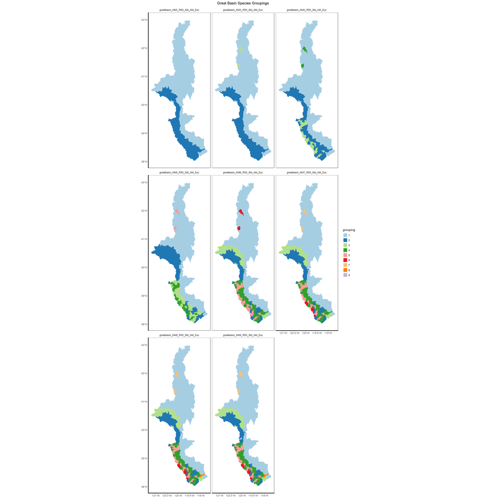

```r
species_info$region_map  # print the map
```

```r
species_lists <- species_lists_by_group_dfs(species_info$species_data, region_name)  # species_info$species_data is the data frame for the region

for(df in species_lists){
  show(knitr::kable(df, format="html"))
}
```

| group_1 | group_2 |
| --- | --- |
| Sacramento_speckled_dace | Lahontan_speckled_dace |
| Lahontan_speckled_dace | Lahontan_mountain_sucker |
| NA | Mountain_whitefish |
| NA | Lahontan_cutthroat_trout |

| group_1 | group_2 | group_3 |
| --- | --- | --- |
| Lahontan_speckled_dace | Lahontan_speckled_dace | Sacramento_speckled_dace |
| NA | Lahontan_mountain_sucker | NA |
| NA | Mountain_whitefish | NA |
| NA | Lahontan_cutthroat_trout | NA |

| group_1 | group_2 | group_3 | group_4 |
| --- | --- | --- | --- |
| Lahontan_speckled_dace | Lahontan_speckled_dace | Lahontan_speckled_dace | Sacramento_speckled_dace |
| NA | Lahontan_mountain_sucker | Lahontan_mountain_sucker | NA |
| NA | Mountain_whitefish | Mountain_whitefish | NA |
| NA | NA | Lahontan_cutthroat_trout | NA |

| group_1 | group_2 | group_3 | group_4 | group_5 |
| --- | --- | --- | --- | --- |
| NA | Lahontan_speckled_dace | Lahontan_speckled_dace | Lahontan_speckled_dace | Sacramento_speckled_dace |
| NA | Lahontan_mountain_sucker | Lahontan_mountain_sucker | Lahontan_mountain_sucker | NA |
| NA | NA | Mountain_whitefish | Mountain_whitefish | NA |
| NA | NA | NA | Lahontan_cutthroat_trout | NA |

| group_1 | group_2 | group_3 | group_4 | group_5 | group_6 |
| --- | --- | --- | --- | --- | --- |
| NA | Lahontan_speckled_dace | Lahontan_speckled_dace | Lahontan_speckled_dace | Lahontan_speckled_dace | Sacramento_speckled_dace |
| NA | Lahontan_mountain_sucker | NA | Lahontan_mountain_sucker | Lahontan_mountain_sucker | NA |
| NA | NA | NA | Mountain_whitefish | Mountain_whitefish | NA |
| NA | NA | NA | NA | Lahontan_cutthroat_trout | NA |

| group_1 | group_2 | group_3 | group_4 | group_5 | group_6 | group_7 |
| --- | --- | --- | --- | --- | --- | --- |
| NA | Lahontan_speckled_dace | Lahontan_speckled_dace | Lahontan_speckled_dace | Lahontan_speckled_dace | Lahontan_speckled_dace | Sacramento_speckled_dace |
| NA | Lahontan_mountain_sucker | NA | Lahontan_mountain_sucker | Lahontan_mountain_sucker | Lahontan_mountain_sucker | NA |
| NA | NA | NA | Mountain_whitefish | Mountain_whitefish | Lahontan_cutthroat_trout | NA |
| NA | NA | NA | NA | Lahontan_cutthroat_trout | NA | NA |

| group_1 | group_2 | group_3 | group_4 | group_5 | group_6 | group_7 | group_8 |
| --- | --- | --- | --- | --- | --- | --- | --- |
| NA | Lahontan_speckled_dace | Lahontan_speckled_dace | Lahontan_speckled_dace | Lahontan_speckled_dace | Lahontan_speckled_dace | Sacramento_speckled_dace | Lahontan_speckled_dace |
| NA | Lahontan_mountain_sucker | NA | Lahontan_mountain_sucker | Lahontan_mountain_sucker | Lahontan_mountain_sucker | NA | Mountain_whitefish |
| NA | NA | NA | Mountain_whitefish | Mountain_whitefish | Lahontan_cutthroat_trout | NA | NA |
| NA | NA | NA | NA | Lahontan_cutthroat_trout | NA | NA | NA |

| group_1 | group_2 | group_3 | group_4 | group_5 | group_6 | group_7 | group_8 | group_9 |
| --- | --- | --- | --- | --- | --- | --- | --- | --- |
| NA | Lahontan_speckled_dace | Lahontan_speckled_dace | Lahontan_speckled_dace | Lahontan_speckled_dace | Lahontan_speckled_dace | Sacramento_speckled_dace | Lahontan_speckled_dace | Lahontan_speckled_dace |
| NA | Lahontan_mountain_sucker | NA | Lahontan_mountain_sucker | Lahontan_mountain_sucker | Lahontan_mountain_sucker | NA | Mountain_whitefish | Lahontan_mountain_sucker |
| NA | NA | NA | Mountain_whitefish | Mountain_whitefish | Lahontan_cutthroat_trout | NA | NA | NA |
| NA | NA | NA | NA | Lahontan_cutthroat_trout | NA | NA | NA | NA |

## Coast

```r
region_name = "coast"
species_info <- species_maps(region_name, "Coast")
```

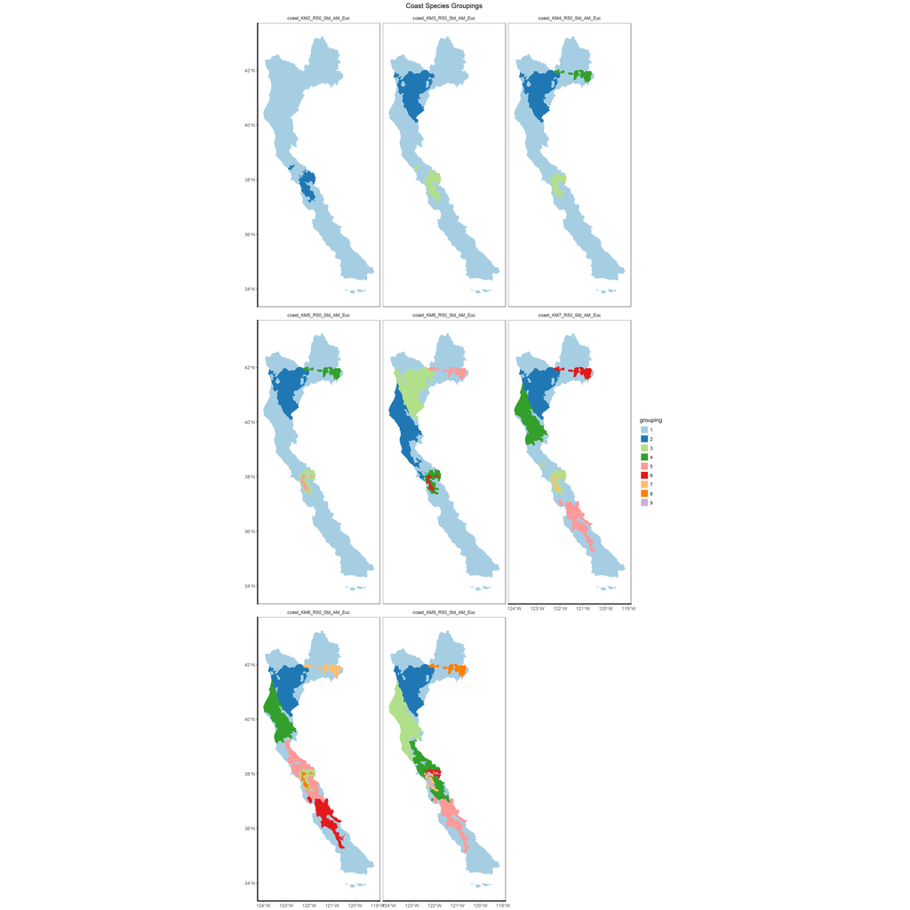

```r
species_info$region_map  # print the map
```

```r
species_lists <- species_lists_by_group_dfs(species_info$species_data, region_name)  # species_info$species_data is the data frame for the region

for(df in species_lists){
  show(knitr::kable(df, format="html"))
}
```

| group_1 | group_2 |
| --- | --- |
| Pacific_lamprey | Pacific_lamprey |
| Klamath_River_lamprey | River_lamprey |
| River_lamprey | Western_brook_lamprey |
| Western_brook_lamprey | Southern_green_sturgeon |
| Northern_green_sturgeon | White_sturgeon |
| White_sturgeon | Sacramento_hitch |
| Blue_chub | Central_California_roach |
| Arroyo_chub | Sacramento_splittail |
| Sacramento_hitch | Hardhead |
| Monterey_hitch | Sacramento_pikeminnow |
| Central_California_roach | Sacramento_sucker |
| Monterey_roach | Longfin_smelt |
| Tomales_roach | Delta_smelt |
| Sacramento_splittail | California_Coast_fall_Chinook_salmon |
| Hardhead | Central_Valley_winter_Chinook_salmon |
| Sacramento_pikeminnow | Central_Valley_spring_Chinook_salmon |
| Sacramento_speckled_dace | Central_Valley_late_fall_Chinook_salmon |
| Sacramento_sucker | Central_Valley_fall_Chinook_salmon |
| Monterey_sucker | Central_Coast_coho_salmon |
| Klamath_largescale_sucker | Central_California_coast_winter_steelhead |
| Lost_River_sucker | Riffle_sculpin |
| Shortnose_sucker | Inland_threespine_stickleback |
| Longfin_smelt | Sacramento_perch |
| Upper_Klamath_Trinity_fall_Chinook_salmon | Sacramento_tule_perch |
| Upper_Klamath_Trinity_spring_Chinook_salm | NA |
| California_Coast_fall_Chinook_salmon | NA |
| Central_Coast_coho_salmon | NA |
| Southern_Oregon_Northern_California_coast | NA |
| Northern_California_coast_winter_steelhea | NA |
| Northern_California_coast_summer_steelhea | NA |
| Klamath_Mountains_Province_winter_steelhe | NA |
| Klamath_Mountains_Province_summer_steelhe | NA |
| Central_California_coast_winter_steelhead | NA |
| South_Central_California_coast_steelhead | NA |
| Southern_California_steelhead | NA |
| Lower_Klamath_marbled_sculpin | NA |
| Upper_Klamath_marbled_sculpin | NA |
| Riffle_sculpin | NA |
| Inland_threespine_stickleback | NA |
| Unarmored_threespine_stickleback | NA |
| Sacramento_perch | NA |
| Sacramento_tule_perch | NA |
| Tidewater_goby | NA |

| group_1 | group_2 | group_3 |
| --- | --- | --- |
| Pacific_lamprey | Pacific_lamprey | Pacific_lamprey |
| Klamath_River_lamprey | Klamath_River_lamprey | River_lamprey |
| River_lamprey | River_lamprey | Western_brook_lamprey |
| Western_brook_lamprey | Western_brook_lamprey | Southern_green_sturgeon |
| Northern_green_sturgeon | Northern_green_sturgeon | White_sturgeon |
| Southern_green_sturgeon | White_sturgeon | Sacramento_hitch |
| White_sturgeon | Longfin_smelt | Central_California_roach |
| Blue_chub | Upper_Klamath_Trinity_fall_Chinook_salmon | Sacramento_splittail |
| Arroyo_chub | Upper_Klamath_Trinity_spring_Chinook_salm | Hardhead |
| Sacramento_hitch | Southern_Oregon_Northern_California_coast | Sacramento_pikeminnow |
| Monterey_hitch | Klamath_Mountains_Province_winter_steelhe | Sacramento_sucker |
| Central_California_roach | Klamath_Mountains_Province_summer_steelhe | Longfin_smelt |
| Monterey_roach | Lower_Klamath_marbled_sculpin | Delta_smelt |
| Tomales_roach | Inland_threespine_stickleback | California_Coast_fall_Chinook_salmon |
| Sacramento_splittail | Tidewater_goby | Central_Valley_winter_Chinook_salmon |
| Hardhead | NA | Central_Valley_spring_Chinook_salmon |
| Sacramento_pikeminnow | NA | Central_Valley_late_fall_Chinook_salmon |
| Sacramento_speckled_dace | NA | Central_Valley_fall_Chinook_salmon |
| Sacramento_sucker | NA | Central_Coast_coho_salmon |
| Monterey_sucker | NA | Central_California_coast_winter_steelhead |
| Klamath_largescale_sucker | NA | Riffle_sculpin |
| Lost_River_sucker | NA | Inland_threespine_stickleback |
| Shortnose_sucker | NA | Sacramento_perch |
| Longfin_smelt | NA | Sacramento_tule_perch |
| California_Coast_fall_Chinook_salmon | NA | NA |
| Central_Coast_coho_salmon | NA | NA |
| Southern_Oregon_Northern_California_coast | NA | NA |
| Northern_California_coast_winter_steelhea | NA | NA |
| Northern_California_coast_summer_steelhea | NA | NA |
| Klamath_Mountains_Province_winter_steelhe | NA | NA |
| Klamath_Mountains_Province_summer_steelhe | NA | NA |
| Central_California_coast_winter_steelhead | NA | NA |
| South_Central_California_coast_steelhead | NA | NA |
| Southern_California_steelhead | NA | NA |
| Upper_Klamath_marbled_sculpin | NA | NA |
| Riffle_sculpin | NA | NA |
| Inland_threespine_stickleback | NA | NA |
| Unarmored_threespine_stickleback | NA | NA |
| Sacramento_perch | NA | NA |
| Sacramento_tule_perch | NA | NA |
| Tidewater_goby | NA | NA |

| group_1 | group_2 | group_3 | group_4 |
| --- | --- | --- | --- |
| Pacific_lamprey | Pacific_lamprey | Pacific_lamprey | Pacific_lamprey |
| Klamath_River_lamprey | Klamath_River_lamprey | River_lamprey | Klamath_River_lamprey |
| River_lamprey | River_lamprey | Western_brook_lamprey | Blue_chub |
| Western_brook_lamprey | Western_brook_lamprey | Southern_green_sturgeon | Klamath_largescale_sucker |
| Northern_green_sturgeon | Northern_green_sturgeon | White_sturgeon | Lost_River_sucker |
| Southern_green_sturgeon | White_sturgeon | Sacramento_hitch | Shortnose_sucker |
| White_sturgeon | Longfin_smelt | Central_California_roach | Upper_Klamath_marbled_sculpin |
| Blue_chub | Upper_Klamath_Trinity_fall_Chinook_salmon | Sacramento_splittail | Sacramento_perch |
| Arroyo_chub | Upper_Klamath_Trinity_spring_Chinook_salm | Hardhead | NA |
| Sacramento_hitch | Southern_Oregon_Northern_California_coast | Sacramento_pikeminnow | NA |
| Monterey_hitch | Klamath_Mountains_Province_winter_steelhe | Sacramento_sucker | NA |
| Central_California_roach | Klamath_Mountains_Province_summer_steelhe | Longfin_smelt | NA |
| Monterey_roach | Lower_Klamath_marbled_sculpin | Delta_smelt | NA |
| Tomales_roach | Inland_threespine_stickleback | California_Coast_fall_Chinook_salmon | NA |
| Sacramento_splittail | Tidewater_goby | Central_Valley_winter_Chinook_salmon | NA |
| Hardhead | NA | Central_Valley_spring_Chinook_salmon | NA |
| Sacramento_pikeminnow | NA | Central_Valley_late_fall_Chinook_salmon | NA |
| Sacramento_speckled_dace | NA | Central_Valley_fall_Chinook_salmon | NA |
| Sacramento_sucker | NA | Central_Coast_coho_salmon | NA |
| Monterey_sucker | NA | Central_California_coast_winter_steelhead | NA |
| Klamath_largescale_sucker | NA | Riffle_sculpin | NA |
| Lost_River_sucker | NA | Inland_threespine_stickleback | NA |
| Shortnose_sucker | NA | Sacramento_perch | NA |
| Longfin_smelt | NA | Sacramento_tule_perch | NA |
| California_Coast_fall_Chinook_salmon | NA | NA | NA |
| Central_Coast_coho_salmon | NA | NA | NA |
| Southern_Oregon_Northern_California_coast | NA | NA | NA |
| Northern_California_coast_winter_steelhea | NA | NA | NA |
| Northern_California_coast_summer_steelhea | NA | NA | NA |
| Klamath_Mountains_Province_winter_steelhe | NA | NA | NA |
| Klamath_Mountains_Province_summer_steelhe | NA | NA | NA |
| Central_California_coast_winter_steelhead | NA | NA | NA |
| South_Central_California_coast_steelhead | NA | NA | NA |
| Southern_California_steelhead | NA | NA | NA |
| Riffle_sculpin | NA | NA | NA |
| Inland_threespine_stickleback | NA | NA | NA |
| Unarmored_threespine_stickleback | NA | NA | NA |
| Sacramento_perch | NA | NA | NA |
| Sacramento_tule_perch | NA | NA | NA |
| Tidewater_goby | NA | NA | NA |

| group_1 | group_2 | group_3 | group_4 | group_5 |
| --- | --- | --- | --- | --- |
| Pacific_lamprey | Pacific_lamprey | Pacific_lamprey | Pacific_lamprey | Pacific_lamprey |
| Klamath_River_lamprey | Klamath_River_lamprey | River_lamprey | Klamath_River_lamprey | River_lamprey |
| River_lamprey | River_lamprey | Western_brook_lamprey | Blue_chub | Western_brook_lamprey |
| Western_brook_lamprey | Western_brook_lamprey | Southern_green_sturgeon | Klamath_largescale_sucker | Southern_green_sturgeon |
| Northern_green_sturgeon | Northern_green_sturgeon | White_sturgeon | Lost_River_sucker | White_sturgeon |
| Southern_green_sturgeon | White_sturgeon | Sacramento_hitch | Shortnose_sucker | Sacramento_hitch |
| White_sturgeon | Longfin_smelt | Central_California_roach | Upper_Klamath_marbled_sculpin | Sacramento_splittail |
| Blue_chub | Upper_Klamath_Trinity_fall_Chinook_salmon | Sacramento_splittail | Sacramento_perch | Longfin_smelt |
| Arroyo_chub | Upper_Klamath_Trinity_spring_Chinook_salm | Hardhead | NA | Delta_smelt |
| Sacramento_hitch | Southern_Oregon_Northern_California_coast | Sacramento_pikeminnow | NA | Central_Valley_winter_Chinook_salmon |
| Monterey_hitch | Klamath_Mountains_Province_winter_steelhe | Sacramento_sucker | NA | Central_Valley_spring_Chinook_salmon |
| Central_California_roach | Klamath_Mountains_Province_summer_steelhe | Longfin_smelt | NA | Central_Valley_late_fall_Chinook_salmon |
| Monterey_roach | Lower_Klamath_marbled_sculpin | Delta_smelt | NA | Central_Valley_fall_Chinook_salmon |
| Tomales_roach | Inland_threespine_stickleback | California_Coast_fall_Chinook_salmon | NA | Central_California_coast_winter_steelhead |
| Sacramento_splittail | Tidewater_goby | Central_Valley_spring_Chinook_salmon | NA | Inland_threespine_stickleback |
| Hardhead | NA | Central_Coast_coho_salmon | NA | Sacramento_tule_perch |
| Sacramento_pikeminnow | NA | Central_California_coast_winter_steelhead | NA | NA |
| Sacramento_speckled_dace | NA | Riffle_sculpin | NA | NA |
| Sacramento_sucker | NA | Inland_threespine_stickleback | NA | NA |
| Monterey_sucker | NA | Sacramento_perch | NA | NA |
| Klamath_largescale_sucker | NA | Sacramento_tule_perch | NA | NA |
| Lost_River_sucker | NA | NA | NA | NA |
| Shortnose_sucker | NA | NA | NA | NA |
| Longfin_smelt | NA | NA | NA | NA |
| California_Coast_fall_Chinook_salmon | NA | NA | NA | NA |
| Central_Coast_coho_salmon | NA | NA | NA | NA |
| Southern_Oregon_Northern_California_coast | NA | NA | NA | NA |
| Northern_California_coast_winter_steelhea | NA | NA | NA | NA |
| Northern_California_coast_summer_steelhea | NA | NA | NA | NA |
| Klamath_Mountains_Province_winter_steelhe | NA | NA | NA | NA |
| Klamath_Mountains_Province_summer_steelhe | NA | NA | NA | NA |
| Central_California_coast_winter_steelhead | NA | NA | NA | NA |
| South_Central_California_coast_steelhead | NA | NA | NA | NA |
| Southern_California_steelhead | NA | NA | NA | NA |
| Riffle_sculpin | NA | NA | NA | NA |
| Inland_threespine_stickleback | NA | NA | NA | NA |
| Unarmored_threespine_stickleback | NA | NA | NA | NA |
| Sacramento_perch | NA | NA | NA | NA |
| Sacramento_tule_perch | NA | NA | NA | NA |
| Tidewater_goby | NA | NA | NA | NA |

| group_1 | group_2 | group_3 | group_4 | group_5 | group_6 |
| --- | --- | --- | --- | --- | --- |
| Pacific_lamprey | Pacific_lamprey | Pacific_lamprey | Pacific_lamprey | Pacific_lamprey | Pacific_lamprey |
| Klamath_River_lamprey | River_lamprey | Klamath_River_lamprey | River_lamprey | Klamath_River_lamprey | River_lamprey |
| River_lamprey | Western_brook_lamprey | River_lamprey | Western_brook_lamprey | Blue_chub | Western_brook_lamprey |
| Western_brook_lamprey | Northern_green_sturgeon | Western_brook_lamprey | Southern_green_sturgeon | Klamath_largescale_sucker | Southern_green_sturgeon |
| Southern_green_sturgeon | White_sturgeon | Northern_green_sturgeon | White_sturgeon | Lost_River_sucker | White_sturgeon |
| White_sturgeon | Sacramento_hitch | White_sturgeon | Sacramento_hitch | Shortnose_sucker | Sacramento_hitch |
| Blue_chub | Central_California_roach | Longfin_smelt | Central_California_roach | Upper_Klamath_marbled_sculpin | Sacramento_splittail |
| Arroyo_chub | Tomales_roach | Upper_Klamath_Trinity_fall_Chinook_salmon | Sacramento_splittail | Sacramento_perch | Longfin_smelt |
| Sacramento_hitch | Hardhead | Upper_Klamath_Trinity_spring_Chinook_salm | Hardhead | NA | Delta_smelt |
| Monterey_hitch | Sacramento_pikeminnow | Southern_Oregon_Northern_California_coast | Sacramento_pikeminnow | NA | Central_Valley_winter_Chinook_salmon |
| Central_California_roach | Sacramento_sucker | Klamath_Mountains_Province_winter_steelhe | Sacramento_sucker | NA | Central_Valley_spring_Chinook_salmon |
| Monterey_roach | Longfin_smelt | Klamath_Mountains_Province_summer_steelhe | Delta_smelt | NA | Central_Valley_late_fall_Chinook_salmon |
| Sacramento_splittail | California_Coast_fall_Chinook_salmon | Lower_Klamath_marbled_sculpin | Central_Valley_spring_Chinook_salmon | NA | Central_Valley_fall_Chinook_salmon |
| Hardhead | Central_Coast_coho_salmon | Inland_threespine_stickleback | Central_California_coast_winter_steelhead | NA | Central_California_coast_winter_steelhead |
| Sacramento_pikeminnow | Southern_Oregon_Northern_California_coast | Tidewater_goby | Riffle_sculpin | NA | Inland_threespine_stickleback |
| Sacramento_speckled_dace | Northern_California_coast_winter_steelhea | NA | Inland_threespine_stickleback | NA | Sacramento_tule_perch |
| Sacramento_sucker | Northern_California_coast_summer_steelhea | NA | Sacramento_perch | NA | NA |
| Monterey_sucker | Central_California_coast_winter_steelhead | NA | Sacramento_tule_perch | NA | NA |
| Klamath_largescale_sucker | Riffle_sculpin | NA | NA | NA | NA |
| Lost_River_sucker | Inland_threespine_stickleback | NA | NA | NA | NA |
| Shortnose_sucker | Tidewater_goby | NA | NA | NA | NA |
| California_Coast_fall_Chinook_salmon | NA | NA | NA | NA | NA |
| Central_Coast_coho_salmon | NA | NA | NA | NA | NA |
| Southern_Oregon_Northern_California_coast | NA | NA | NA | NA | NA |
| Northern_California_coast_winter_steelhea | NA | NA | NA | NA | NA |
| Northern_California_coast_summer_steelhea | NA | NA | NA | NA | NA |
| Klamath_Mountains_Province_winter_steelhe | NA | NA | NA | NA | NA |
| Klamath_Mountains_Province_summer_steelhe | NA | NA | NA | NA | NA |
| Central_California_coast_winter_steelhead | NA | NA | NA | NA | NA |
| South_Central_California_coast_steelhead | NA | NA | NA | NA | NA |
| Southern_California_steelhead | NA | NA | NA | NA | NA |
| Riffle_sculpin | NA | NA | NA | NA | NA |
| Inland_threespine_stickleback | NA | NA | NA | NA | NA |
| Unarmored_threespine_stickleback | NA | NA | NA | NA | NA |
| Sacramento_perch | NA | NA | NA | NA | NA |
| Sacramento_tule_perch | NA | NA | NA | NA | NA |
| Tidewater_goby | NA | NA | NA | NA | NA |

| group_1 | group_2 | group_3 | group_4 | group_5 | group_6 | group_7 |
| --- | --- | --- | --- | --- | --- | --- |
| Pacific_lamprey | Pacific_lamprey | Pacific_lamprey | Pacific_lamprey | Pacific_lamprey | Pacific_lamprey | Pacific_lamprey |
| Klamath_River_lamprey | Klamath_River_lamprey | River_lamprey | River_lamprey | Monterey_hitch | Klamath_River_lamprey | River_lamprey |
| River_lamprey | River_lamprey | Western_brook_lamprey | Western_brook_lamprey | Monterey_roach | Blue_chub | Western_brook_lamprey |
| Western_brook_lamprey | Western_brook_lamprey | Southern_green_sturgeon | Northern_green_sturgeon | Sacramento_pikeminnow | Klamath_largescale_sucker | Southern_green_sturgeon |
| Northern_green_sturgeon | Northern_green_sturgeon | White_sturgeon | White_sturgeon | Sacramento_speckled_dace | Lost_River_sucker | White_sturgeon |
| Southern_green_sturgeon | White_sturgeon | Sacramento_hitch | Central_California_roach | Monterey_sucker | Shortnose_sucker | Sacramento_hitch |
| White_sturgeon | Longfin_smelt | Central_California_roach | Sacramento_pikeminnow | Central_California_coast_winter_steelhead | Upper_Klamath_marbled_sculpin | Sacramento_splittail |
| Blue_chub | Upper_Klamath_Trinity_fall_Chinook_salmon | Sacramento_splittail | Longfin_smelt | South_Central_California_coast_steelhead | Sacramento_perch | Longfin_smelt |
| Arroyo_chub | Upper_Klamath_Trinity_spring_Chinook_salm | Hardhead | California_Coast_fall_Chinook_salmon | Riffle_sculpin | NA | Delta_smelt |
| Sacramento_hitch | Southern_Oregon_Northern_California_coast | Sacramento_pikeminnow | Central_Coast_coho_salmon | Inland_threespine_stickleback | NA | Central_Valley_winter_Chinook_salmon |
| Monterey_hitch | Klamath_Mountains_Province_winter_steelhe | Sacramento_sucker | Southern_Oregon_Northern_California_coast | Tidewater_goby | NA | Central_Valley_spring_Chinook_salmon |
| Central_California_roach | Klamath_Mountains_Province_summer_steelhe | Longfin_smelt | Northern_California_coast_winter_steelhea | NA | NA | Central_Valley_late_fall_Chinook_salmon |
| Monterey_roach | Lower_Klamath_marbled_sculpin | Delta_smelt | Northern_California_coast_summer_steelhea | NA | NA | Central_Valley_fall_Chinook_salmon |
| Tomales_roach | Inland_threespine_stickleback | California_Coast_fall_Chinook_salmon | Inland_threespine_stickleback | NA | NA | Central_California_coast_winter_steelhead |
| Sacramento_splittail | Tidewater_goby | Central_Valley_spring_Chinook_salmon | Tidewater_goby | NA | NA | Inland_threespine_stickleback |
| Hardhead | NA | Central_Coast_coho_salmon | NA | NA | NA | Sacramento_tule_perch |
| Sacramento_pikeminnow | NA | Central_California_coast_winter_steelhead | NA | NA | NA | NA |
| Sacramento_speckled_dace | NA | Riffle_sculpin | NA | NA | NA | NA |
| Sacramento_sucker | NA | Inland_threespine_stickleback | NA | NA | NA | NA |
| Monterey_sucker | NA | Sacramento_perch | NA | NA | NA | NA |
| Klamath_largescale_sucker | NA | Sacramento_tule_perch | NA | NA | NA | NA |
| Lost_River_sucker | NA | NA | NA | NA | NA | NA |
| Shortnose_sucker | NA | NA | NA | NA | NA | NA |
| California_Coast_fall_Chinook_salmon | NA | NA | NA | NA | NA | NA |
| Central_Coast_coho_salmon | NA | NA | NA | NA | NA | NA |
| Southern_Oregon_Northern_California_coast | NA | NA | NA | NA | NA | NA |
| Northern_California_coast_winter_steelhea | NA | NA | NA | NA | NA | NA |
| Northern_California_coast_summer_steelhea | NA | NA | NA | NA | NA | NA |
| Klamath_Mountains_Province_winter_steelhe | NA | NA | NA | NA | NA | NA |
| Klamath_Mountains_Province_summer_steelhe | NA | NA | NA | NA | NA | NA |
| Central_California_coast_winter_steelhead | NA | NA | NA | NA | NA | NA |
| South_Central_California_coast_steelhead | NA | NA | NA | NA | NA | NA |
| Southern_California_steelhead | NA | NA | NA | NA | NA | NA |
| Riffle_sculpin | NA | NA | NA | NA | NA | NA |
| Inland_threespine_stickleback | NA | NA | NA | NA | NA | NA |
| Unarmored_threespine_stickleback | NA | NA | NA | NA | NA | NA |
| Sacramento_perch | NA | NA | NA | NA | NA | NA |
| Sacramento_tule_perch | NA | NA | NA | NA | NA | NA |
| Tidewater_goby | NA | NA | NA | NA | NA | NA |

| group_1 | group_2 | group_3 | group_4 | group_5 | group_6 | group_7 | group_8 |
| --- | --- | --- | --- | --- | --- | --- | --- |
| Pacific_lamprey | Pacific_lamprey | Pacific_lamprey | Pacific_lamprey | Pacific_lamprey | Pacific_lamprey | Pacific_lamprey | Pacific_lamprey |
| Klamath_River_lamprey | Klamath_River_lamprey | River_lamprey | River_lamprey | River_lamprey | Monterey_hitch | Klamath_River_lamprey | River_lamprey |
| River_lamprey | River_lamprey | Western_brook_lamprey | Western_brook_lamprey | Western_brook_lamprey | Monterey_roach | Blue_chub | Western_brook_lamprey |
| Western_brook_lamprey | Western_brook_lamprey | Southern_green_sturgeon | Northern_green_sturgeon | Southern_green_sturgeon | Sacramento_pikeminnow | Klamath_largescale_sucker | Southern_green_sturgeon |
| Northern_green_sturgeon | Northern_green_sturgeon | White_sturgeon | White_sturgeon | White_sturgeon | Sacramento_speckled_dace | Lost_River_sucker | White_sturgeon |
| Southern_green_sturgeon | White_sturgeon | Sacramento_hitch | Central_California_roach | Sacramento_hitch | Monterey_sucker | Shortnose_sucker | Sacramento_hitch |
| White_sturgeon | Longfin_smelt | Central_California_roach | Sacramento_pikeminnow | Central_California_roach | Central_California_coast_winter_steelhead | Upper_Klamath_marbled_sculpin | Sacramento_splittail |
| Blue_chub | Upper_Klamath_Trinity_fall_Chinook_salmon | Sacramento_splittail | Sacramento_sucker | Tomales_roach | South_Central_California_coast_steelhead | Sacramento_perch | Longfin_smelt |
| Arroyo_chub | Upper_Klamath_Trinity_spring_Chinook_salm | Hardhead | Longfin_smelt | Sacramento_splittail | Riffle_sculpin | NA | Delta_smelt |
| Monterey_hitch | Southern_Oregon_Northern_California_coast | Sacramento_pikeminnow | California_Coast_fall_Chinook_salmon | Hardhead | Inland_threespine_stickleback | NA | Central_Valley_winter_Chinook_salmon |
| Central_California_roach | Klamath_Mountains_Province_winter_steelhe | Sacramento_sucker | Central_Coast_coho_salmon | Sacramento_pikeminnow | Tidewater_goby | NA | Central_Valley_spring_Chinook_salmon |
| Monterey_roach | Klamath_Mountains_Province_summer_steelhe | Delta_smelt | Southern_Oregon_Northern_California_coast | Sacramento_sucker | NA | NA | Central_Valley_late_fall_Chinook_salmon |
| Sacramento_splittail | Lower_Klamath_marbled_sculpin | Central_Valley_spring_Chinook_salmon | Northern_California_coast_winter_steelhea | Longfin_smelt | NA | NA | Central_Valley_fall_Chinook_salmon |
| Sacramento_pikeminnow | Inland_threespine_stickleback | Central_California_coast_winter_steelhead | Northern_California_coast_summer_steelhea | California_Coast_fall_Chinook_salmon | NA | NA | Central_California_coast_winter_steelhead |
| Sacramento_speckled_dace | Tidewater_goby | Riffle_sculpin | Inland_threespine_stickleback | Central_Coast_coho_salmon | NA | NA | Inland_threespine_stickleback |
| Sacramento_sucker | NA | Inland_threespine_stickleback | Tidewater_goby | Central_California_coast_winter_steelhead | NA | NA | Sacramento_tule_perch |
| Monterey_sucker | NA | Sacramento_perch | NA | Riffle_sculpin | NA | NA | NA |
| Klamath_largescale_sucker | NA | Sacramento_tule_perch | NA | Inland_threespine_stickleback | NA | NA | NA |
| Lost_River_sucker | NA | NA | NA | Sacramento_perch | NA | NA | NA |
| Shortnose_sucker | NA | NA | NA | Sacramento_tule_perch | NA | NA | NA |
| California_Coast_fall_Chinook_salmon | NA | NA | NA | Tidewater_goby | NA | NA | NA |
| Central_Coast_coho_salmon | NA | NA | NA | NA | NA | NA | NA |
| Southern_Oregon_Northern_California_coast | NA | NA | NA | NA | NA | NA | NA |
| Northern_California_coast_winter_steelhea | NA | NA | NA | NA | NA | NA | NA |
| Northern_California_coast_summer_steelhea | NA | NA | NA | NA | NA | NA | NA |
| Klamath_Mountains_Province_winter_steelhe | NA | NA | NA | NA | NA | NA | NA |
| Klamath_Mountains_Province_summer_steelhe | NA | NA | NA | NA | NA | NA | NA |
| Central_California_coast_winter_steelhead | NA | NA | NA | NA | NA | NA | NA |
| South_Central_California_coast_steelhead | NA | NA | NA | NA | NA | NA | NA |
| Southern_California_steelhead | NA | NA | NA | NA | NA | NA | NA |
| Inland_threespine_stickleback | NA | NA | NA | NA | NA | NA | NA |
| Unarmored_threespine_stickleback | NA | NA | NA | NA | NA | NA | NA |
| Sacramento_perch | NA | NA | NA | NA | NA | NA | NA |
| Sacramento_tule_perch | NA | NA | NA | NA | NA | NA | NA |
| Tidewater_goby | NA | NA | NA | NA | NA | NA | NA |

| group_1 | group_2 | group_3 | group_4 | group_5 | group_6 | group_7 | group_8 | group_9 |
| --- | --- | --- | --- | --- | --- | --- | --- | --- |
| Pacific_lamprey | Pacific_lamprey | Pacific_lamprey | Pacific_lamprey | Pacific_lamprey | Pacific_lamprey | Pacific_lamprey | Pacific_lamprey | Pacific_lamprey |
| Klamath_River_lamprey | Klamath_River_lamprey | River_lamprey | River_lamprey | Monterey_hitch | River_lamprey | River_lamprey | Klamath_River_lamprey | River_lamprey |
| River_lamprey | River_lamprey | Western_brook_lamprey | Western_brook_lamprey | Monterey_roach | Western_brook_lamprey | Western_brook_lamprey | Blue_chub | Western_brook_lamprey |
| Western_brook_lamprey | Western_brook_lamprey | Northern_green_sturgeon | Southern_green_sturgeon | Sacramento_pikeminnow | Southern_green_sturgeon | Southern_green_sturgeon | Klamath_largescale_sucker | Southern_green_sturgeon |
| Southern_green_sturgeon | Northern_green_sturgeon | White_sturgeon | White_sturgeon | Sacramento_speckled_dace | White_sturgeon | White_sturgeon | Lost_River_sucker | White_sturgeon |
| White_sturgeon | White_sturgeon | Central_California_roach | Sacramento_hitch | Monterey_sucker | Sacramento_hitch | Sacramento_hitch | Shortnose_sucker | Sacramento_hitch |
| Blue_chub | Longfin_smelt | Sacramento_pikeminnow | Central_California_roach | Central_California_coast_winter_steelhead | Central_California_roach | Central_California_roach | Upper_Klamath_marbled_sculpin | Sacramento_splittail |
| Arroyo_chub | Upper_Klamath_Trinity_fall_Chinook_salmon | Sacramento_sucker | Tomales_roach | South_Central_California_coast_steelhead | Sacramento_splittail | Sacramento_splittail | Sacramento_perch | Longfin_smelt |
| Monterey_hitch | Upper_Klamath_Trinity_spring_Chinook_salm | Longfin_smelt | Sacramento_splittail | Riffle_sculpin | Hardhead | Sacramento_pikeminnow | NA | Delta_smelt |
| Central_California_roach | Southern_Oregon_Northern_California_coast | California_Coast_fall_Chinook_salmon | Hardhead | Inland_threespine_stickleback | Sacramento_pikeminnow | Sacramento_sucker | NA | Central_Valley_winter_Chinook_salmon |
| Monterey_roach | Klamath_Mountains_Province_winter_steelhe | Central_Coast_coho_salmon | Sacramento_pikeminnow | Tidewater_goby | Sacramento_sucker | Central_Valley_spring_Chinook_salmon | NA | Central_Valley_spring_Chinook_salmon |
| Sacramento_splittail | Klamath_Mountains_Province_summer_steelhe | Southern_Oregon_Northern_California_coast | Sacramento_sucker | NA | Delta_smelt | Central_California_coast_winter_steelhead | NA | Central_Valley_late_fall_Chinook_salmon |
| Sacramento_pikeminnow | Lower_Klamath_marbled_sculpin | Northern_California_coast_winter_steelhea | Longfin_smelt | NA | Central_California_coast_winter_steelhead | Riffle_sculpin | NA | Central_Valley_fall_Chinook_salmon |
| Sacramento_speckled_dace | Inland_threespine_stickleback | Northern_California_coast_summer_steelhea | California_Coast_fall_Chinook_salmon | NA | Inland_threespine_stickleback | Sacramento_perch | NA | Central_California_coast_winter_steelhead |
| Sacramento_sucker | Tidewater_goby | Inland_threespine_stickleback | Central_Coast_coho_salmon | NA | Sacramento_tule_perch | Sacramento_tule_perch | NA | Inland_threespine_stickleback |
| Monterey_sucker | NA | Tidewater_goby | Central_California_coast_winter_steelhead | NA | NA | NA | NA | Sacramento_tule_perch |
| Klamath_largescale_sucker | NA | NA | Riffle_sculpin | NA | NA | NA | NA | NA |
| Lost_River_sucker | NA | NA | Inland_threespine_stickleback | NA | NA | NA | NA | NA |
| Shortnose_sucker | NA | NA | Sacramento_perch | NA | NA | NA | NA | NA |
| California_Coast_fall_Chinook_salmon | NA | NA | Sacramento_tule_perch | NA | NA | NA | NA | NA |
| Central_Coast_coho_salmon | NA | NA | Tidewater_goby | NA | NA | NA | NA | NA |
| Southern_Oregon_Northern_California_coast | NA | NA | NA | NA | NA | NA | NA | NA |
| Northern_California_coast_winter_steelhea | NA | NA | NA | NA | NA | NA | NA | NA |
| Northern_California_coast_summer_steelhea | NA | NA | NA | NA | NA | NA | NA | NA |
| Klamath_Mountains_Province_winter_steelhe | NA | NA | NA | NA | NA | NA | NA | NA |
| Klamath_Mountains_Province_summer_steelhe | NA | NA | NA | NA | NA | NA | NA | NA |
| Central_California_coast_winter_steelhead | NA | NA | NA | NA | NA | NA | NA | NA |
| South_Central_California_coast_steelhead | NA | NA | NA | NA | NA | NA | NA | NA |
| Southern_California_steelhead | NA | NA | NA | NA | NA | NA | NA | NA |
| Inland_threespine_stickleback | NA | NA | NA | NA | NA | NA | NA | NA |
| Unarmored_threespine_stickleback | NA | NA | NA | NA | NA | NA | NA | NA |
| Sacramento_perch | NA | NA | NA | NA | NA | NA | NA | NA |
| Sacramento_tule_perch | NA | NA | NA | NA | NA | NA | NA | NA |
| Tidewater_goby | NA | NA | NA | NA | NA | NA | NA | NA |

## Desert

```r
region_name = "desert"
species_info <- species_maps(region_name, "Desert")
```

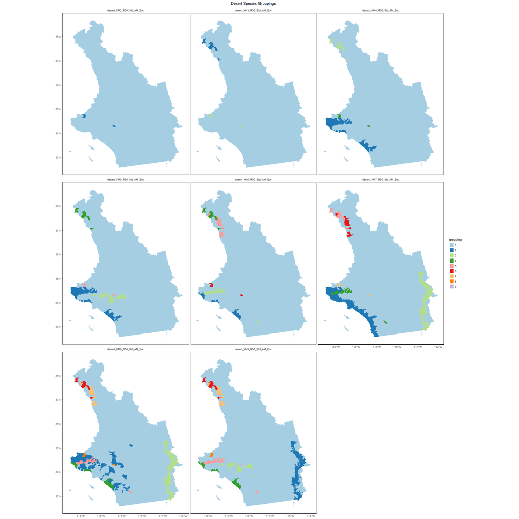

```r
species_info$region_map  # print the map
```

```r
species_lists <- species_lists_by_group_dfs(species_info$species_data, region_name)  # species_info$species_data is the data frame for the region

for(df in species_lists){
  show(knitr::kable(df, format="html"))
}
```

| group_1 | group_2 |
| --- | --- |
| Pacific_lamprey | Arroyo_chub |
| Owens_tui_chub | Sacramento_hitch |
| Arroyo_chub | Central_California_roach |
| Sacramento_hitch | Sacramento_splittail |
| Central_California_roach | Sacramento_tule_perch |
| Owens_speckled_dace | NA |
| Santa_Ana_speckled_dace | NA |
| Santa_Ana_sucker | NA |
| Razorback_sucker | NA |
| Southern_California_steelhead | NA |
| Lahontan_cutthroat_trout | NA |
| Desert_pupfish | NA |
| Owens_pupfish | NA |
| Inland_threespine_stickleback | NA |
| Unarmored_threespine_stickleback | NA |
| Sacramento_perch | NA |
| Tidewater_goby | NA |

| group_1 | group_2 | group_3 |
| --- | --- | --- |
| Pacific_lamprey | Owens_tui_chub | Arroyo_chub |
| Owens_tui_chub | Owens_speckled_dace | Sacramento_hitch |
| Arroyo_chub | Lahontan_cutthroat_trout | Central_California_roach |
| Sacramento_hitch | Inland_threespine_stickleback | Sacramento_splittail |
| Central_California_roach | Sacramento_perch | Sacramento_tule_perch |
| Owens_speckled_dace | NA | NA |
| Santa_Ana_speckled_dace | NA | NA |
| Santa_Ana_sucker | NA | NA |
| Razorback_sucker | NA | NA |
| Southern_California_steelhead | NA | NA |
| Desert_pupfish | NA | NA |
| Owens_pupfish | NA | NA |
| Inland_threespine_stickleback | NA | NA |
| Unarmored_threespine_stickleback | NA | NA |
| Tidewater_goby | NA | NA |

| group_1 | group_2 | group_3 | group_4 |
| --- | --- | --- | --- |
| Pacific_lamprey | Pacific_lamprey | Owens_tui_chub | Arroyo_chub |
| Owens_tui_chub | Arroyo_chub | Owens_speckled_dace | Sacramento_hitch |
| Arroyo_chub | Santa_Ana_sucker | Lahontan_cutthroat_trout | Central_California_roach |
| Sacramento_hitch | Southern_California_steelhead | Inland_threespine_stickleback | Sacramento_splittail |
| Central_California_roach | Inland_threespine_stickleback | Sacramento_perch | Sacramento_tule_perch |
| Owens_speckled_dace | Unarmored_threespine_stickleback | NA | NA |
| Santa_Ana_speckled_dace | Tidewater_goby | NA | NA |
| Santa_Ana_sucker | NA | NA | NA |
| Razorback_sucker | NA | NA | NA |
| Desert_pupfish | NA | NA | NA |
| Owens_pupfish | NA | NA | NA |
| Inland_threespine_stickleback | NA | NA | NA |
| Unarmored_threespine_stickleback | NA | NA | NA |

| group_1 | group_2 | group_3 | group_4 | group_5 |
| --- | --- | --- | --- | --- |
| Pacific_lamprey | Pacific_lamprey | Arroyo_chub | Owens_tui_chub | Arroyo_chub |
| Owens_tui_chub | Arroyo_chub | Santa_Ana_speckled_dace | Owens_speckled_dace | Sacramento_hitch |
| Arroyo_chub | Santa_Ana_sucker | Santa_Ana_sucker | Lahontan_cutthroat_trout | Central_California_roach |
| Sacramento_hitch | Southern_California_steelhead | Inland_threespine_stickleback | Inland_threespine_stickleback | Sacramento_splittail |
| Central_California_roach | Inland_threespine_stickleback | NA | Sacramento_perch | Sacramento_tule_perch |
| Owens_speckled_dace | Unarmored_threespine_stickleback | NA | NA | NA |
| Santa_Ana_sucker | Tidewater_goby | NA | NA | NA |
| Razorback_sucker | NA | NA | NA | NA |
| Desert_pupfish | NA | NA | NA | NA |
| Owens_pupfish | NA | NA | NA | NA |
| Inland_threespine_stickleback | NA | NA | NA | NA |
| Unarmored_threespine_stickleback | NA | NA | NA | NA |

| group_1 | group_2 | group_3 | group_4 | group_5 | group_6 |
| --- | --- | --- | --- | --- | --- |
| Pacific_lamprey | Pacific_lamprey | Pacific_lamprey | Owens_tui_chub | Owens_tui_chub | Arroyo_chub |
| Arroyo_chub | Arroyo_chub | Arroyo_chub | Owens_speckled_dace | Owens_speckled_dace | Sacramento_hitch |
| Sacramento_hitch | Santa_Ana_sucker | Santa_Ana_sucker | Lahontan_cutthroat_trout | Owens_pupfish | Central_California_roach |
| Central_California_roach | Southern_California_steelhead | Southern_California_steelhead | Inland_threespine_stickleback | NA | Sacramento_splittail |
| Owens_speckled_dace | Inland_threespine_stickleback | Unarmored_threespine_stickleback | Sacramento_perch | NA | Sacramento_tule_perch |
| Santa_Ana_speckled_dace | Tidewater_goby | NA | NA | NA | NA |
| Santa_Ana_sucker | NA | NA | NA | NA | NA |
| Razorback_sucker | NA | NA | NA | NA | NA |
| Southern_California_steelhead | NA | NA | NA | NA | NA |
| Desert_pupfish | NA | NA | NA | NA | NA |
| Inland_threespine_stickleback | NA | NA | NA | NA | NA |

| group_1 | group_2 | group_3 | group_4 | group_5 | group_6 | group_7 |
| --- | --- | --- | --- | --- | --- | --- |
| Arroyo_chub | Pacific_lamprey | Razorback_sucker | Pacific_lamprey | Owens_tui_chub | Owens_tui_chub | Arroyo_chub |
| Sacramento_hitch | Arroyo_chub | NA | Arroyo_chub | Owens_speckled_dace | Owens_speckled_dace | Sacramento_hitch |
| Central_California_roach | Santa_Ana_sucker | NA | Santa_Ana_sucker | Lahontan_cutthroat_trout | Owens_pupfish | Central_California_roach |
| Owens_speckled_dace | Southern_California_steelhead | NA | Southern_California_steelhead | Inland_threespine_stickleback | NA | Sacramento_splittail |
| Santa_Ana_speckled_dace | Inland_threespine_stickleback | NA | Unarmored_threespine_stickleback | Sacramento_perch | NA | Sacramento_tule_perch |
| Santa_Ana_sucker | Tidewater_goby | NA | NA | NA | NA | NA |
| Desert_pupfish | NA | NA | NA | NA | NA | NA |
| Inland_threespine_stickleback | NA | NA | NA | NA | NA | NA |

| group_1 | group_2 | group_3 | group_4 | group_5 | group_6 | group_7 | group_8 |
| --- | --- | --- | --- | --- | --- | --- | --- |
| Pacific_lamprey | Pacific_lamprey | Razorback_sucker | Pacific_lamprey | Pacific_lamprey | Owens_tui_chub | Owens_tui_chub | Arroyo_chub |
| Owens_speckled_dace | Arroyo_chub | NA | Arroyo_chub | Arroyo_chub | Owens_speckled_dace | Owens_speckled_dace | Sacramento_hitch |
| Santa_Ana_speckled_dace | Sacramento_hitch | NA | Santa_Ana_sucker | Santa_Ana_sucker | Lahontan_cutthroat_trout | Owens_pupfish | Central_California_roach |
| Santa_Ana_sucker | Central_California_roach | NA | Southern_California_steelhead | Southern_California_steelhead | Inland_threespine_stickleback | NA | Sacramento_splittail |
| Southern_California_steelhead | Santa_Ana_speckled_dace | NA | Inland_threespine_stickleback | Unarmored_threespine_stickleback | Sacramento_perch | NA | Sacramento_tule_perch |
| Desert_pupfish | Santa_Ana_sucker | NA | Tidewater_goby | NA | NA | NA | NA |
| Inland_threespine_stickleback | Southern_California_steelhead | NA | NA | NA | NA | NA | NA |
| NA | Inland_threespine_stickleback | NA | NA | NA | NA | NA | NA |

| group_1 | group_2 | group_3 | group_4 | group_5 | group_6 | group_7 | group_8 | group_9 |
| --- | --- | --- | --- | --- | --- | --- | --- | --- |
| Pacific_lamprey | Razorback_sucker | Arroyo_chub | Pacific_lamprey | Pacific_lamprey | Owens_tui_chub | Owens_tui_chub | Arroyo_chub | Arroyo_chub |
| Arroyo_chub | NA | Santa_Ana_speckled_dace | Arroyo_chub | Arroyo_chub | Owens_speckled_dace | Owens_speckled_dace | Sacramento_hitch | Sacramento_hitch |
| Sacramento_hitch | NA | Santa_Ana_sucker | Santa_Ana_sucker | Santa_Ana_sucker | Lahontan_cutthroat_trout | Owens_pupfish | Central_California_roach | Sacramento_splittail |
| Central_California_roach | NA | Inland_threespine_stickleback | Southern_California_steelhead | Southern_California_steelhead | Inland_threespine_stickleback | NA | Sacramento_tule_perch | Sacramento_tule_perch |
| Owens_speckled_dace | NA | NA | Inland_threespine_stickleback | Unarmored_threespine_stickleback | Sacramento_perch | NA | NA | NA |
| Santa_Ana_sucker | NA | NA | Tidewater_goby | NA | NA | NA | NA | NA |
| Southern_California_steelhead | NA | NA | NA | NA | NA | NA | NA | NA |
| Desert_pupfish | NA | NA | NA | NA | NA | NA | NA | NA |
| Inland_threespine_stickleback | NA | NA | NA | NA | NA | NA | NA | NA |